# Supporting democracy from the school

A comparison of four Latin American countries

Daniel Miranda, Ph.D. Centro de Medición MIDE UC, Centro para el Estudio del Conflito y la Cohesión Social COES

Juan Carlos Castillo, Ph.D. Instituto de Sociología ISUC, Centro para el Estudio del Conflito y la Cohesión Social COES.

Julio de 2018

Abstract

The political landscape in Latin America over the last 50 years is characterized by a series of military coups and dictatorships. Although nowadays most of the countries have (at least) electoral democracy, results from international survey studies in Latin American adult population - such as Latinobarometro and the Latin American Public Opinion Project (LAPOP) - still show a worrying proportion of citizens skeptical of democracy as well as decreasing levels of trust in political institutions. The present chapter deals with how anti-democratic beliefs are expressed by children of school age in Latin America, how has it changed over the past decade and to what extent schools are able to impact students in this realm. The analyses are based on the Latin American module of the International Civic and Citizenship Education Study, considering the countries of the region that participated in 2009 and 2016: Mexico, Colombia, Dominican Republic and Chile (N=22558 and N=20150, respectively). Results show that student from this set of Latin American countries shows higher level of antidemocratic beliefs, manifested in a high proportion of students that believe that dictatorship are justified when they brings order and safety or economic benefits. Between 2009 and 2016, the trend indicates that these beliefs are decreased, but in Dominican Republic it was increased. Considering the role of the schools, results indicate that the extent to which students obtain higher knowledge about the political system and it rules they diminish the support for antidemocratic beliefs in an important size. This association is stronger in families with higher education. This indicates that students who came from families with higher educational levels take advantages over the school as a source of knowledge about political space, showing a stratified process of socialization of democratic and anti-democratic beliefs. Implications for public policies with a focus in Latin American students will be discussed.

## Outline

- The entire proposal should be no more than 1 page long.
- An abstract of approximately 300 words that describes your ideas for addressing a particular concept, with the theory/ies you will advance or the theorist/s you will use, the key argument you will make, the regions addressed and youth studies issues that will be engaged in their chapter.
- A brief outline of the proposed chapter including sub-headings and the focus of each sub-section.
  - Introduction
    - Democratic development of Latin American countries and its threats
    - Support for democratic values and antidemocratic values
    - Political Socialization of democratics principles
  - Data and Methods
    - ICCS study 2009 and 2016
    - Variables
    - Analitycal estrategy
  - Results
  - Discussion and Conclussion
- A short biosketch (150 word maximum) that includes your research areas, national origin, current institution and motivation for involvement in this project.
  - Daniel Miranda is a researcher at the Measurement Center MIDE UC, Pontificia Universidad Católica de Chile (PUC) and Adjunct researcher at the Centre for Social Conflict and Cohesion Studies COES. He obtained his Ph.D in sociology at the Sociology Institute, PUC, Santiago of Chile. Among his current research interest are political socialization processes, youth political participation and attitudes, intergroup relations, intergroup attitudes, public opinion research and quantitative methods.

## Lectura de datos

```r
##Directorio para imagenes
setwd("C:/Users/DANIEL/Dropbox/MIDEUC/Corruption and trust/figures")

iccs16=read.dta13("C:/Users/DANIEL/Dropbox/GEMR 2019/Data/Merge/ICCS_School_Teachers_Students_Europe_LA.dta", convert.factors = FALSE)

iccs09=read.dta13("C:/Users/DANIEL/Dropbox/mesa educacion ciudadana/IEA studies/ICCS/Internacional/LA_ICCS.dta", convert.factors = FALSE)



#iccs=haven::read_dta("C:/Users/DANIEL/Dropbox/MIDEUC/Corruption and trust/ICCS2016.dta")

## Explorar la base

    #class(iccs)
    #dim(iccs)
    #head(iccs)
    #str(iccs)

    #names(iccs09)
    #names(iccs16)

    #dplyr::glimpse(iccs09) # ver estructura general

    la16= iccs16 %>%
      rename_all(tolower) %>%
      mutate(LA = ifelse(country == "CHL", "LA", ifelse(country == "COL", "LA", ifelse(country == "DOM", "LA", ifelse(country == "MEX", "LA", ifelse(country == "PER", "LA", "NOLA")))))) %>%
      dplyr::filter(LA=="LA") %>%
      rowwise() %>%
      dplyr::mutate(study="16") %>%
      dplyr::mutate (dicta1= 5 - ls3g02d)%>%
      dplyr::mutate (dicta2= 5 - ls3g02e)%>%
      dplyr::mutate (dictadura= mean(c(dicta1, dicta2)))%>%
      dplyr::mutate (univ= ifelse(s_hisced>2, 1, 0)) %>%
      dplyr::mutate (civic= mean(c(pv1civ, pv2civ, pv3civ, pv4civ, pv5civ))) %>%
      dplyr::select(idcntry, country, idschool, idstud, totwgts, wgtfac1, wgtadj1s, wgtfac2s, wgtadj2s, wgtadj3s, jkzones, jkreps, pv1civ, pv2civ, pv3civ, pv4civ, pv5civ, civic, s_intrust, s_opdisc, s_hisced, s_hisei, s_homlit, s_gender, s_citcon, s_citsoc, s_citresp, s_citeff, s_cntatt, s_abuse, s_civlrn, s_geneql, s_ethrght, l_attviol, l_attdiv, l_atths, l_autgov, l_attcorr, l_dislaw, l_empclas, study, dicta1, dicta2, dictadura, univ)
    #print
    #names(la16)
    #skim(la16)
    #table(la16$ls3g02d, la16$ls3g02e)
    #pacman::p_load(Hmisc)
    #rcorr(la16$ls3g02d, la16$ls3g02b)


    la09= iccs09 %>%
      rowwise() %>%
      dplyr::mutate(study="09") %>%
      dplyr::mutate (civic= mean(c(pv1civ, pv2civ, pv3civ, pv4civ, pv5civ))) %>%
      dplyr::mutate (s_intrust= intrust) %>%
      dplyr::mutate (s_opdisc= opdisc) %>%
      dplyr::mutate (s_hisced= hisced) %>%
      dplyr::mutate (s_hisei= hisei) %>%
      dplyr::mutate (s_homlit= homelit) %>%
      dplyr::mutate (s_gender= sgender) %>%
      dplyr::mutate (s_citcon= citcon) %>%
      dplyr::mutate (s_citsoc= citsoc) %>%
      dplyr::mutate (s_citeff= citeff) %>%
      dplyr::mutate (s_cntatt= attcnt) %>%
      dplyr::mutate (s_geneql= geneql) %>%
      dplyr::mutate (s_ethrght= ethrght) %>%
      dplyr::mutate (l_attviol= attviol) %>%
      dplyr::mutate (l_attdiv= attdiff) %>%
      dplyr::mutate (l_autgov= autgov) %>%
      dplyr::mutate (l_attcorr=attcorr) %>%
      dplyr::mutate (l_dislaw= dislaw) %>%
      dplyr::mutate (l_empclas= empath) %>%
      dplyr::mutate (dicta1= 5 - LS2P03D)%>%
      dplyr::mutate (dicta2= 5 - LS2P03E)%>%
      dplyr::mutate (dictadura= mean(c(dicta1, dicta2)))%>%
      dplyr::mutate (univ= ifelse(s_hisced>3, 1, 0)) %>%
      dplyr::select(idcntry, country, idschool, idstud, totwgts, wgtfac1, wgtadj1s, wgtfac2s, wgtadj2s, wgtadj3s, jkzones, jkreps, pv1civ, pv2civ, pv3civ, pv4civ, pv5civ, civic, s_intrust, s_opdisc, s_hisced, s_hisei, s_homlit, s_gender, s_citcon, s_citsoc, s_citeff, s_cntatt, s_geneql, s_ethrght, expagg, l_attviol, l_attdiv, l_autgov, l_attcorr, l_dislaw, l_empclas, study, dicta1, dicta2, dictadura, univ)

    #print
    #names(la09)
    #skim(la09)

    mergeiccs=full_join(la16, la09)
    #names(mergeiccs)
    #View(merge)
    #table(mergeiccs$univ)

    mergeiccs %>%
      group_by(study) %>%
      skimr::skim(c(civic, l_attviol, l_attdiv, l_autgov, l_attcorr, l_dislaw, l_empclas, dictadura, univ))
```

```
## Skim summary statistics
##  n obs: 55281
##  n variables: 46
##  group variables: study
##
## -- Variable type:numeric -------------------------------------------------------------------------------------
##  study  variable missing complete     n   mean    sd     p0    p25    p50
##     09     civic       0    29962 29962 446.77 84.46 156.84 385.28 441.38
##     09 dictadura    1343    28619 29962   2.79  0.74   1      2.5    3
##     09 l_attcorr     758    29204 29962  49.59 10.16  26.05  44.59  51.12
##     09  l_attdiv     827    29135 29962  50.4  10.1   10.55  44.5   48.89
##     09 l_attviol    1150    28812 29962  50.06 10.07  28.02  46.33  50.36
##     09  l_autgov     315    29647 29962  49.49 10.26  15.98  44.38  51.14
##     09  l_dislaw     777    29185 29962  49.71 10.22   6.29  45.01  50.05
##     09 l_empclas     981    28981 29962  49.68  9.91  14.09  43.03  49.12
##     09      univ     253    29709 29962   0.33  0.47   0      0      0
##     16     civic       0    25319 25319 458.34 90.82 140.98 391.62 461.86
##     16 dictadura     760    24559 25319   2.76  0.8    1      2.5    3
##     16 l_attcorr     391    24928 25319  50.27  9.98  29.14  45.02  51.18
##     16  l_attdiv     476    24843 25319  50.23  9.87  16.82  47.29  55.65
##     16 l_attviol     520    24799 25319  48.53 10.66  28.12  43.03  51.23
##     16  l_autgov     197    25122 25319  49.09 11.1   17.67  42.55  51.06
##     16  l_dislaw     399    24920 25319  49.57 11.06  12.5   44.37  49.53
##     16 l_empclas     424    24895 25319  49.89  9.87   9.55  42.71  50.87
##     16      univ     271    25048 25319   0.41  0.49   0      0      0
##     p75   p100     hist
##  505.94 780.39 ▁▁▆▇▆▃▁▁
##    3      4    ▁▁▃▅▁▇▃▂
##   56.42  79.61 ▂▂▃▇▇▃▁▁
##   55.43  76.72 ▁▁▁▃▇▃▂▁
##   56.45  75.52 ▂▂▂▇▆▃▁▁
##   55.42  86.25 ▁▁▂▆▇▂▁▁
##   54.75  90.39 ▁▁▁▆▇▂▁▁
##   56.29  64.03 ▁▁▁▃▇▇▇▇
##    1      1    ▇▁▁▁▁▁▁▃
##  526.04 733.37 ▁▁▃▇▇▆▂▁
##    3      4    ▂▁▃▃▁▇▃▂
##   56.37  76.76 ▂▂▃▇▇▃▁▁
##   55.65  55.65 ▁▁▁▁▁▁▁▇
##   55.6   76.64 ▃▅▅▇▇▃▁▁
##   55.6   85.37 ▁▂▅▇▇▃▁▁
##   55.81  83.67 ▁▁▂▇▇▃▁▁
##   61.55  61.55 ▁▁▁▂▃▇▅▇
##    1      1    ▇▁▁▁▁▁▁▆
```

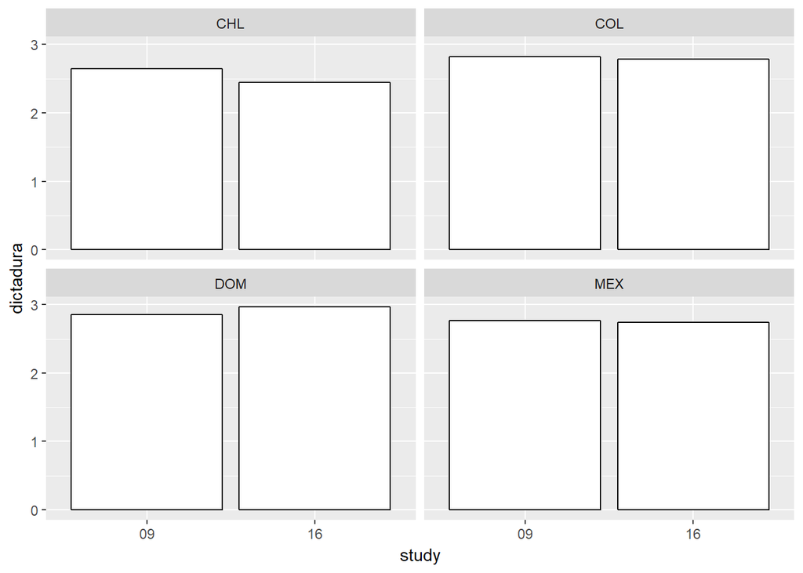

```r
    merge4=mergeiccs %>%
      filter(country=="CHL" | country=="COL" | country=="MEX" | country=="DOM")



#iccsp= corr %>%
#  na.omit() %>%
#  print

    ggplot(merge4, aes(x=study, y=dictadura)) +
      facet_wrap(~ country) +
      stat_summary(fun.y = mean, geom = "bar", fill = "White", colour = "Black")
```

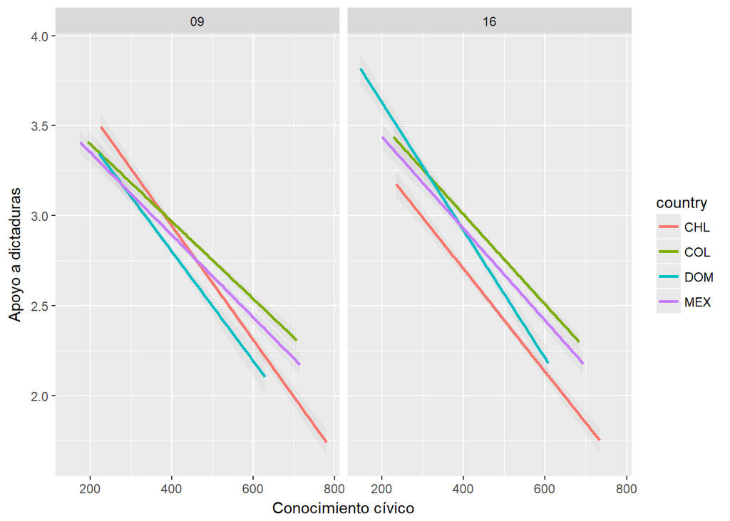

```r
    scatter <- ggplot(merge4, aes(civic, dictadura, colour = factor(country)))
    scatter + geom_smooth(method = "lm", alpha = 0.1) +
      facet_wrap(~ study) +
    labs(x = "Conocimiento cívico", y = "Apoyo a dictaduras", colour = "country")
```

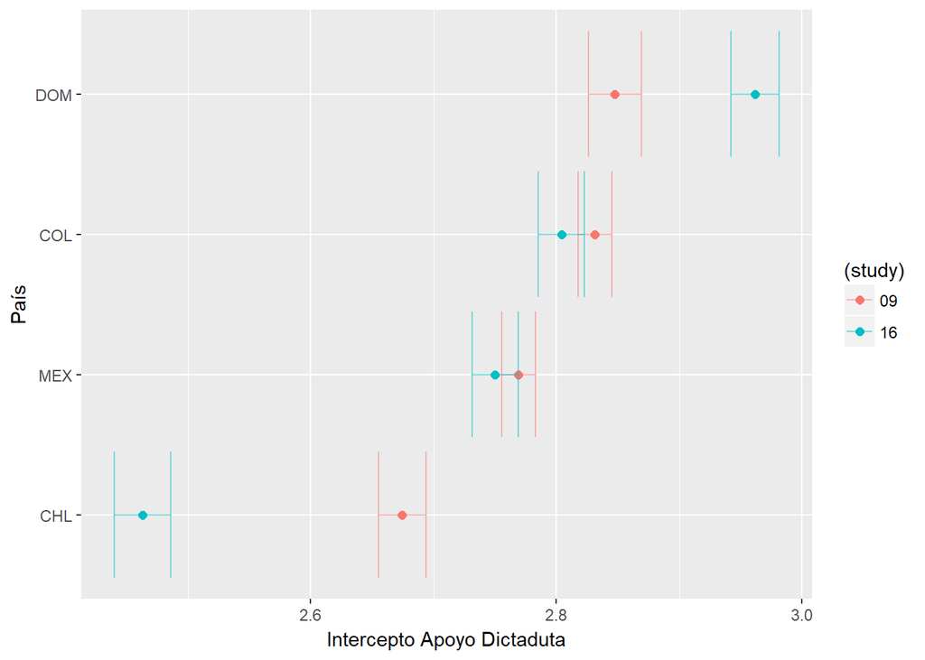

```r
## Análisis de Frecuencias: srsvy

## crear un objeto con el diseño
    #library(srvyr)

    mergesvy <-  merge4 %>%
        as_survey_design(
        strata = jkzones,
        weights = totwgts,
        ids = jkreps,
        nest = TRUE)

    #names(mergesvy)
    #str(mergesvy)

    #merge= merge4 %>%
    #  na.omit()


## Diferencias Autoritarismo de Gobierno
    res=merge4 %>%
      group_by(country, study) %>%
      do(model = lmer(dictadura ~ 1 + (1 | idschool),weights=totwgts, data = .))

    #res %>%
    #  tidy(model)

    mod=res %>%
      tidy(model)%>%
      filter(group=="fixed")

    ggplot(mod, aes(estimate, reorder(country, estimate), color = (study))) +
      geom_point(size = 2)+
      labs(x = 'Intercepto Apoyo Dictaduta', y = 'País')+
    geom_errorbarh(aes(xmin = estimate - std.error, xmax = estimate + std.error), alpha=1/2)
```

## Regression model

Statistical models

|  | **Model 1** | **Model 2** |  |
| --- | --- | --- | --- |
| (Intercept) | 3.84*** | 3.66*** |  |
|  | (0.02) | (0.03) |  |
| study16 | 0.01 | 0.01* |  |
|  | (0.01) | (0.01) |  |
| univ | -0.06*** | 0.45*** |  |
|  | (0.01) | (0.05) |  |
| civic | -0.00*** | -0.00*** |  |
|  | (0.00) | (0.00) |  |
| univ:civic |  | -0.00*** |  |
|  |  | (0.00) |  |
| AIC | 110435.61 | 110328.24 |  |
| BIC | 110487.30 | 110388.54 |  |
| Log Likelihood | -55211.81 | -55157.12 |  |
| Num. obs. | 40714 | 40714 |  |
| Num. groups: idschool | 233 | 233 |  |
| Var: idschool (Intercept) | 0.01 | 0.01 |  |
| Var: Residual | 79.07 | 78.84 |  |
| p < 0.001, p < 0.01, p < 0.05 |  |  |  |

## Respresentación de la interacción

```r
#----Graficar la interacción
s_civotro = -0.00189 + 0*-0.001083
s_civuni = -0.00189 + 1*-0.001083

i_civotro = 3.66 + 0*0.453
i_civuni = 3.66 + 1*0.453


x0 <‐ mergeiccs$civic
x0=as.numeric(x0)

ed.esp <‐ data.frame(x0 = x0)
ed.esp$y0 <‐ i_civuni + ed.esp$x0 * s_civuni
ed.esp$type <‐ ("Universitario")



ed.otro <‐ data.frame(x0 = x0)
ed.otro$y0 <‐ i_civotro + ed.otro$x0*s_civotro
ed.otro$type <‐ ("Otro")


## Create final data frame
df.ed <‐ rbind(ed.esp, ed.otro)
df.ed$type <‐ factor(df.ed$type)
levels(df.ed$type)
```

```
## [1] "Otro"          "Universitario"
```

```r
skimr::skim(df.ed)
```

```
## Skim summary statistics
##  n obs: 110562
##  n variables: 3
##
## -- Variable type:factor --------------------------------------------------------------------------------------
##  variable missing complete      n n_unique                    top_counts
##      type       0   110562 110562        2 Otr: 55281, Uni: 55281, NA: 0
##  ordered
##    FALSE
##
## -- Variable type:numeric -------------------------------------------------------------------------------------
##  variable missing complete      n   mean    sd     p0    p25    p50    p75
##        x0       0   110562 110562 452.07 87.62 140.98 387.96 450.06 515.44
##        y0       0   110562 110562   2.79  0.22   1.79   2.64   2.8    2.94
##    p100     hist
##  780.39 ▁▁▅▇▇▃▁▁
##    3.69 ▁▁▂▆▇▃▁▁
```

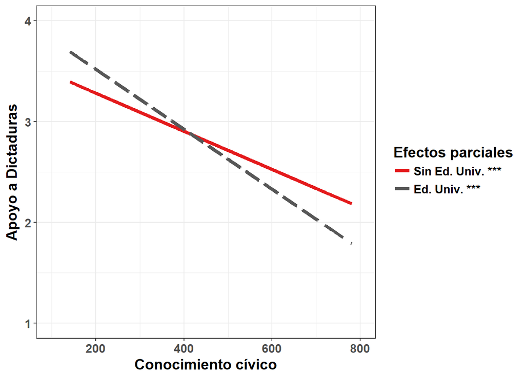

```r
ed= ggplot (df.ed, aes(x = x0, y = y0) ) +
  xlim(xmin=100,xmax=800)+
  ylim(xmin=1,xmax=4)+
  labs(y= "Apoyo a Dictaduras", x="Conocimiento cívico")+ geom_line(aes(colour = type, linetype = type), size=1.5) +
  #geom_jitter(data, aes(x = x, y = y), size = 3, alpha = 0. 7) +
  theme_bw() +
  theme(panel.background = element_rect(fill="white") ) +
  theme(legend.key = element_blank() ) +
  theme(text = element_text(size = 14, face="bold")) +
  scale_colour_manual(name = "Efectos parciales",
                      labels= c ("Sin Ed. Univ. ***","Ed. Univ. ***") ,
                      values = c ("#E41A1C", "#575757"))+
  scale_linetype_manual(name = "Efectos parciales",
                        labels= c ("Sin Ed. Univ. ***","Ed. Univ. ***"),
                        values = c ("solid", "longdash"))
print(ed)
```